# Red wine analysis by sujay

# introduction

This project will apply exploratory data analysis techniques using R to a dataset about chemical properties of Red Wines in order to answer the following question: “Which chemical properties influence the quality of red wines?” The dataset to be explored contains information about 1,599 red wines with 11 variables on the chemical properties of the wine. The quality of each wine is rated between 3(bad) and 8(good) by at least 3 wine experts.

# Univariate Plots

## summary of data

```
## [1] 1599   13
```

This data consist of 1599 rows and 13 columns.

```
##  [1] "X"                    "fixed.acidity"        "volatile.acidity"
##  [4] "citric.acid"          "residual.sugar"       "chlorides"
##  [7] "free.sulfur.dioxide"  "total.sulfur.dioxide" "density"
## [10] "pH"                   "sulphates"            "alcohol"
## [13] "quality"
```

Names of 13 columns.

```
## 'data.frame':    1599 obs. of  13 variables:
##  $ X                   : int  1 2 3 4 5 6 7 8 9 10 ...
##  $ fixed.acidity       : num  7.4 7.8 7.8 11.2 7.4 7.4 7.9 7.3 7.8 7.5 ...
##  $ volatile.acidity    : num  0.7 0.88 0.76 0.28 0.7 0.66 0.6 0.65 0.58 0.5 ...
##  $ citric.acid         : num  0 0 0.04 0.56 0 0 0.06 0 0.02 0.36 ...
##  $ residual.sugar      : num  1.9 2.6 2.3 1.9 1.9 1.8 1.6 1.2 2 6.1 ...
##  $ chlorides           : num  0.076 0.098 0.092 0.075 0.076 0.075 0.069 0.065 0.073 0.071 ...
##  $ free.sulfur.dioxide : num  11 25 15 17 11 13 15 15 9 17 ...
##  $ total.sulfur.dioxide: num  34 67 54 60 34 40 59 21 18 102 ...
##  $ density             : num  0.998 0.997 0.997 0.998 0.998 ...
##  $ pH                  : num  3.51 3.2 3.26 3.16 3.51 3.51 3.3 3.39 3.36 3.35 ...
##  $ sulphates           : num  0.56 0.68 0.65 0.58 0.56 0.56 0.46 0.47 0.57 0.8 ...
##  $ alcohol             : num  9.4 9.8 9.8 9.8 9.4 9.4 9.4 10 9.5 10.5 ...
##  $ quality             : int  5 5 5 6 5 5 5 7 7 5 ...
```

```
##        X          fixed.acidity   volatile.acidity  citric.acid
##  Min.   :   1.0   Min.   : 4.60   Min.   :0.1200   Min.   :0.000
##  1st Qu.: 400.5   1st Qu.: 7.10   1st Qu.:0.3900   1st Qu.:0.090
##  Median : 800.0   Median : 7.90   Median :0.5200   Median :0.260
##  Mean   : 800.0   Mean   : 8.32   Mean   :0.5278   Mean   :0.271
##  3rd Qu.:1199.5   3rd Qu.: 9.20   3rd Qu.:0.6400   3rd Qu.:0.420
##  Max.   :1599.0   Max.   :15.90   Max.   :1.5800   Max.   :1.000
##  residual.sugar     chlorides       free.sulfur.dioxide
##  Min.   : 0.900   Min.   :0.01200   Min.   : 1.00
##  1st Qu.: 1.900   1st Qu.:0.07000   1st Qu.: 7.00
##  Median : 2.200   Median :0.07900   Median :14.00
##  Mean   : 2.539   Mean   :0.08747   Mean   :15.87
##  3rd Qu.: 2.600   3rd Qu.:0.09000   3rd Qu.:21.00
##  Max.   :15.500   Max.   :0.61100   Max.   :72.00
##  total.sulfur.dioxide    density             pH          sulphates
##  Min.   :  6.00       Min.   :0.9901   Min.   :2.740   Min.   :0.3300
##  1st Qu.: 22.00       1st Qu.:0.9956   1st Qu.:3.210   1st Qu.:0.5500
##  Median : 38.00       Median :0.9968   Median :3.310   Median :0.6200
##  Mean   : 46.47       Mean   :0.9967   Mean   :3.311   Mean   :0.6581
##  3rd Qu.: 62.00       3rd Qu.:0.9978   3rd Qu.:3.400   3rd Qu.:0.7300
##  Max.   :289.00       Max.   :1.0037   Max.   :4.010   Max.   :2.0000
##     alcohol         quality
##  Min.   : 8.40   Min.   :3.000
##  1st Qu.: 9.50   1st Qu.:5.000
##  Median :10.20   Median :6.000
##  Mean   :10.42   Mean   :5.636
##  3rd Qu.:11.10   3rd Qu.:6.000
##  Max.   :14.90   Max.   :8.000
```

summary of all the variables

## Observations from the Summary

1.There is a big range for sulfur.dioxide (both Free and Total) across the samples.

2.The sample consists of 1599 Red Wine .

4.The quality of the samples range from 3 to 8 with 6 being the median.

5.The range for fixed acidity is quite high with minimum being 4.60 and maximum being 15.9.

6.pH value varies from 2.740 to 4.010 with a median being 3.310.

## Distribution across quality

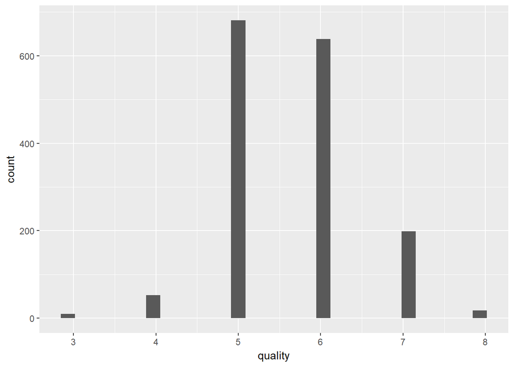

## Normal Distribution of Frequency

The following variables have a normal or close-to-normal distribution: fixed.acidity, volatile.acidity, density, pH and alcohol. Distribution of the variable citric.acid frequency is not normal.

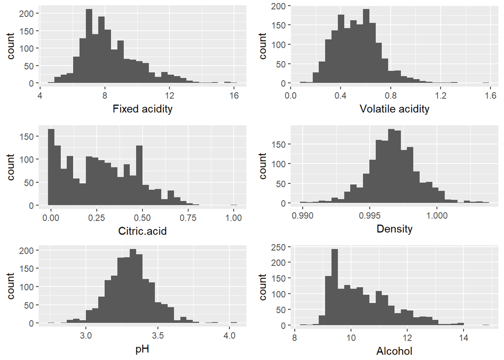

## Transforming Data

The following list of variables is not a normal or close-to-normal distribution: residual.sugar, chlorides, free.sulfur.dioxide, total.sulfur.dioxide and sulphates. The hitograms of all these variables are right-skewed a lot and need some transformation.

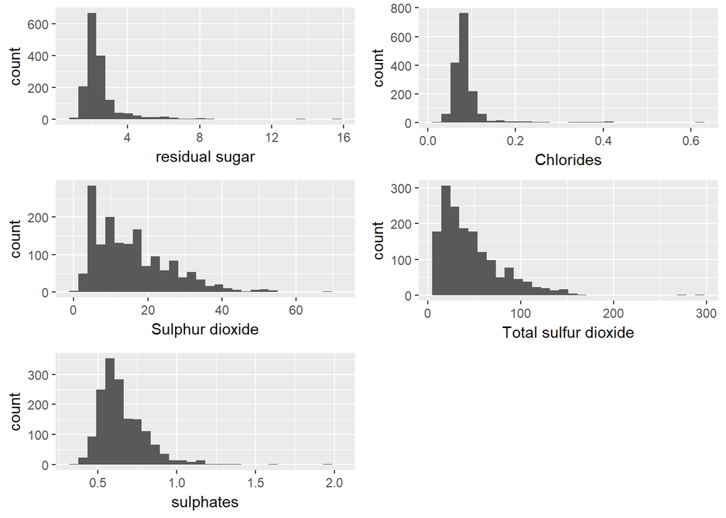

After tranforming data using the log10-transformation to make the data look more like normal distribution.

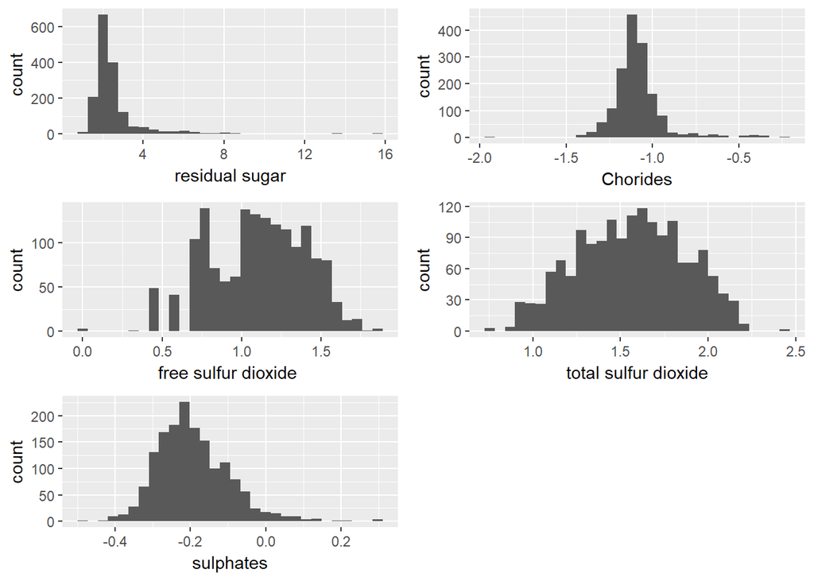

## Adding new variables

### 1.sd_prop

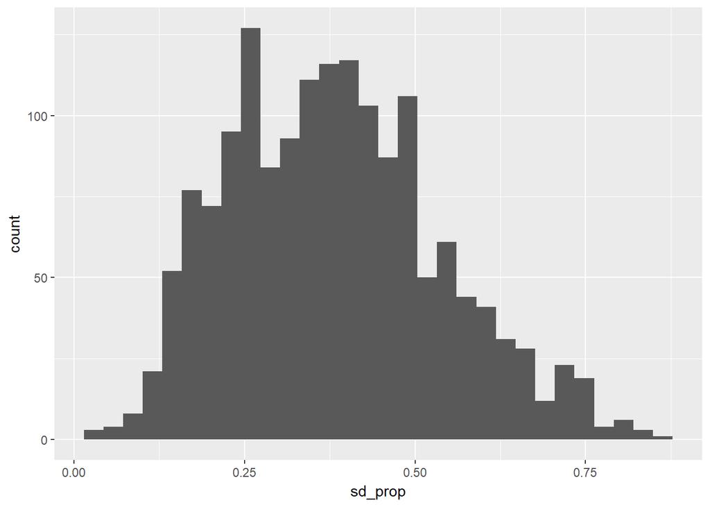

### 2.quality.cat

The variable quality is of numeric type int, which is not convenient for the analysis. So first of all, I change the type of the quality variable to factor and add it to the dataframe as a new variable quality.factor. In addition, I create three categories of quality - good (>= 7), bad (<=4), and medium (5 and 6).For that I created new variable called “quality.cat” in data, In this variable good means quality 7 and 8 wines ,medium consist of quality 5 and 6 wines and bad wines are of quality 3 and 4.

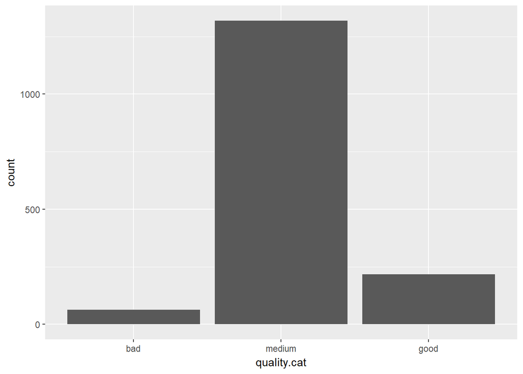

# Univariate Analysis

### What is the structure of your dataset?

I chose to work with the red wine dataset suggested by Udacity. It contains 1,599 observations of 12 variables. All of the variables are numeric, except quality, which is an integer. Other than the quality rating, all of the variables are different chemical properties of wine.

### What is/are the main feature(s) of interest in your dataset?

My main interest in the dataset is to explore and better understand which chemical properties influence the quality rating of red wine. Based on the dataset documentation, I think that volatile acidity and citric acid might have the greatest impact on quality.

### What other features in the dataset do you think will help support your into your feature(s) of interest?

I think that it is possible that any of the other chemical variables could impact the quality rating, but I think that the relationships may be hard to quantify because they may not be linear. I think that having so many wines rated a 5 or 6 will make it challenging to put together a strong model.

### Did you create any new variables from existing variables in the dataset?

I created a new variable called sulfur dioxide proportion, which is the proportion of free sulfur dioxide to total sulfur dioxide. Since these two variables naturally have a relationship, I thought that combining them might be beneficial to the analysis.I also created new variable called quality factor for ease of calculation and quality.cat which divides quality in good (>= 7), bad (<=4), and medium (5 and 6)

### Of the features you investigated, were there any unusual distributions? you perform any operations on the data to tidy, adjust, or change the form the data? If so, why did you do this?

There were a few variables with noticeable outliers (volatile acidity, residual sugar, sulphates) that may need to be removed to create useful plots or for use in a model.

# Bivariate Plots Section

In this section, I analyse relationships between wine characteristics and its perceived quality, as well as possible correlations between different characteristics.

Lets look at correlation between different variables.

```
##                      fixed.acidity volatile.acidity citric.acid
## fixed.acidity           1.00000000     -0.256130895  0.67170343
## volatile.acidity       -0.25613089      1.000000000 -0.55249568
## citric.acid             0.67170343     -0.552495685  1.00000000
## residual.sugar          0.11477672      0.001917882  0.14357716
## chlorides               0.09370519      0.061297772  0.20382291
## free.sulfur.dioxide    -0.15379419     -0.010503827 -0.06097813
## total.sulfur.dioxide   -0.11318144      0.076470005  0.03553302
## density                 0.66804729      0.022026232  0.36494718
## pH                     -0.68297819      0.234937294 -0.54190414
## sulphates               0.18300566     -0.260986685  0.31277004
## alcohol                -0.06166827     -0.202288027  0.10990325
## quality                 0.12405165     -0.390557780  0.22637251
## sd_prop                -0.13081236     -0.072618561 -0.16693889
##                      residual.sugar    chlorides free.sulfur.dioxide
## fixed.acidity           0.114776724  0.093705186        -0.153794193
## volatile.acidity        0.001917882  0.061297772        -0.010503827
## citric.acid             0.143577162  0.203822914        -0.060978129
## residual.sugar          1.000000000  0.055609535         0.187048995
## chlorides               0.055609535  1.000000000         0.005562147
## free.sulfur.dioxide     0.187048995  0.005562147         1.000000000
## total.sulfur.dioxide    0.203027882  0.047400468         0.667666450
## density                 0.355283371  0.200632327        -0.021945831
## pH                     -0.085652422 -0.265026131         0.070377499
## sulphates               0.005527121  0.371260481         0.051657572
## alcohol                 0.042075437 -0.221140545        -0.069408354
## quality                 0.013731637 -0.128906560        -0.050656057
## sd_prop                -0.070626080 -0.105156413         0.327240869
##                      total.sulfur.dioxide     density          pH
## fixed.acidity                 -0.11318144  0.66804729 -0.68297819
## volatile.acidity               0.07647000  0.02202623  0.23493729
## citric.acid                    0.03553302  0.36494718 -0.54190414
## residual.sugar                 0.20302788  0.35528337 -0.08565242
## chlorides                      0.04740047  0.20063233 -0.26502613
## free.sulfur.dioxide            0.66766645 -0.02194583  0.07037750
## total.sulfur.dioxide           1.00000000  0.07126948 -0.06649456
## density                        0.07126948  1.00000000 -0.34169933
## pH                            -0.06649456 -0.34169933  1.00000000
## sulphates                      0.04294684  0.14850641 -0.19664760
## alcohol                       -0.20565394 -0.49617977  0.20563251
## quality                       -0.18510029 -0.17491923 -0.05773139
## sd_prop                       -0.37143493 -0.26497991  0.18489507
##                         sulphates     alcohol     quality     sd_prop
## fixed.acidity         0.183005664 -0.06166827  0.12405165 -0.13081236
## volatile.acidity     -0.260986685 -0.20228803 -0.39055778 -0.07261856
## citric.acid           0.312770044  0.10990325  0.22637251 -0.16693889
## residual.sugar        0.005527121  0.04207544  0.01373164 -0.07062608
## chlorides             0.371260481 -0.22114054 -0.12890656 -0.10515641
## free.sulfur.dioxide   0.051657572 -0.06940835 -0.05065606  0.32724087
## total.sulfur.dioxide  0.042946836 -0.20565394 -0.18510029 -0.37143493
## density               0.148506412 -0.49617977 -0.17491923 -0.26497991
## pH                   -0.196647602  0.20563251 -0.05773139  0.18489507
## sulphates             1.000000000  0.09359475  0.25139708 -0.01045914
## alcohol               0.093594750  1.00000000  0.47616632  0.24627450
## quality               0.251397079  0.47616632  1.00000000  0.19411335
## sd_prop              -0.010459139  0.24627450  0.19411335  1.00000000
```

I removed X variable in the data which is not used in any further analysis.

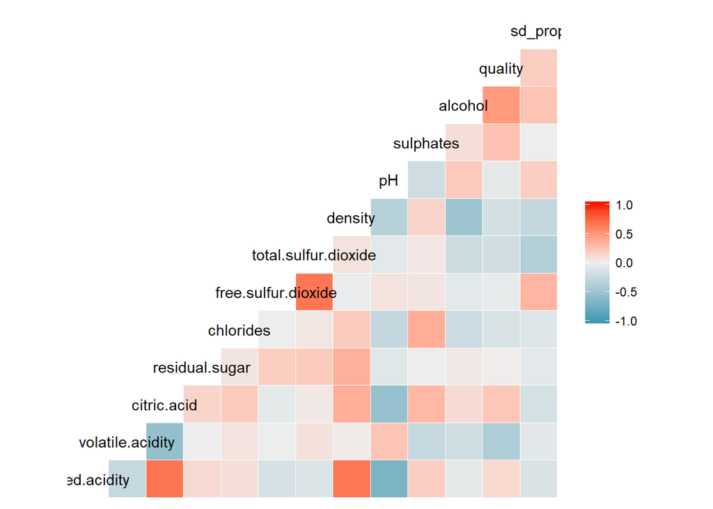

```
##                             [,1]
## fixed.acidity         0.12405165
## volatile.acidity     -0.39055778
## citric.acid           0.22637251
## residual.sugar        0.01373164
## chlorides            -0.12890656
## free.sulfur.dioxide  -0.05065606
## total.sulfur.dioxide -0.18510029
## density              -0.17491923
## pH                   -0.05773139
## sulphates             0.25139708
## alcohol               0.47616632
## quality               1.00000000
## sd_prop               0.19411335
```

From above we see that the following variables are correlated with quality:

Alcohol (+++)

Volatile acidity (-)

Citric acid (++)

Fixed acidity (+)

Sulphates (+)

Total sulphur dioxide (-)

Density (-)

Chlorides (-)

In order to compare statistical data of each variable visually, I use boxplots.

## Increasing Quality of Wine

The following set of boxplots show all the cases when peceived wine quality increases together with increasing values of a characteristic’s variable.

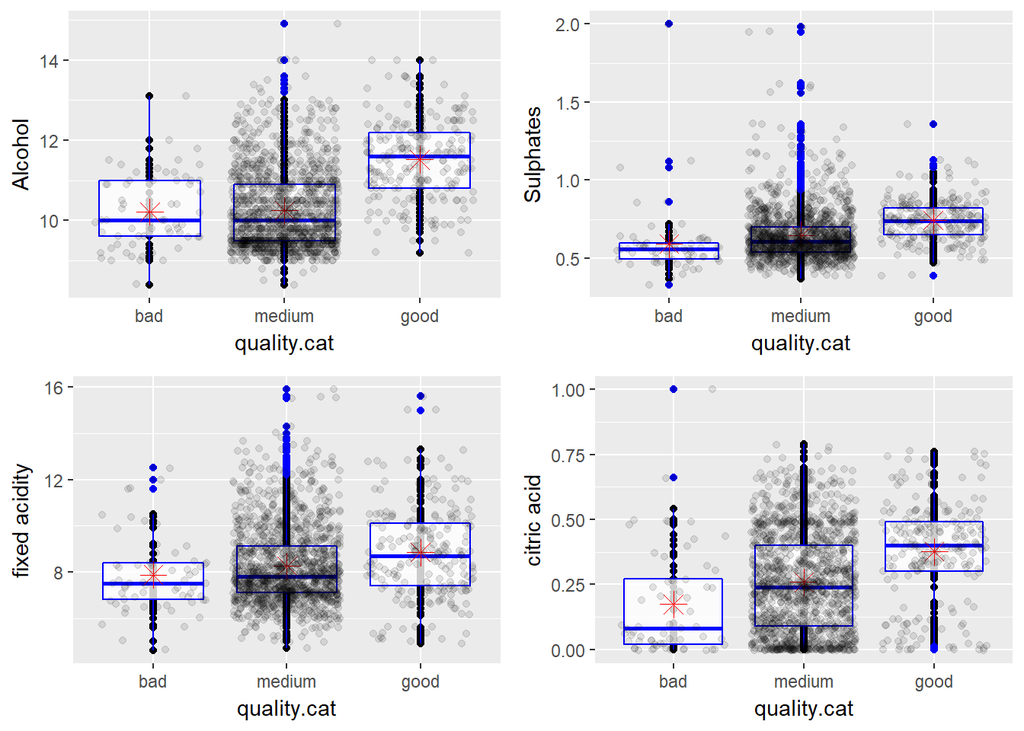

## Decreasing Quality of Wine

The next set of boxplots, on the contrary, show all the cases when peceived wine quality decreases while the values of variables increase.

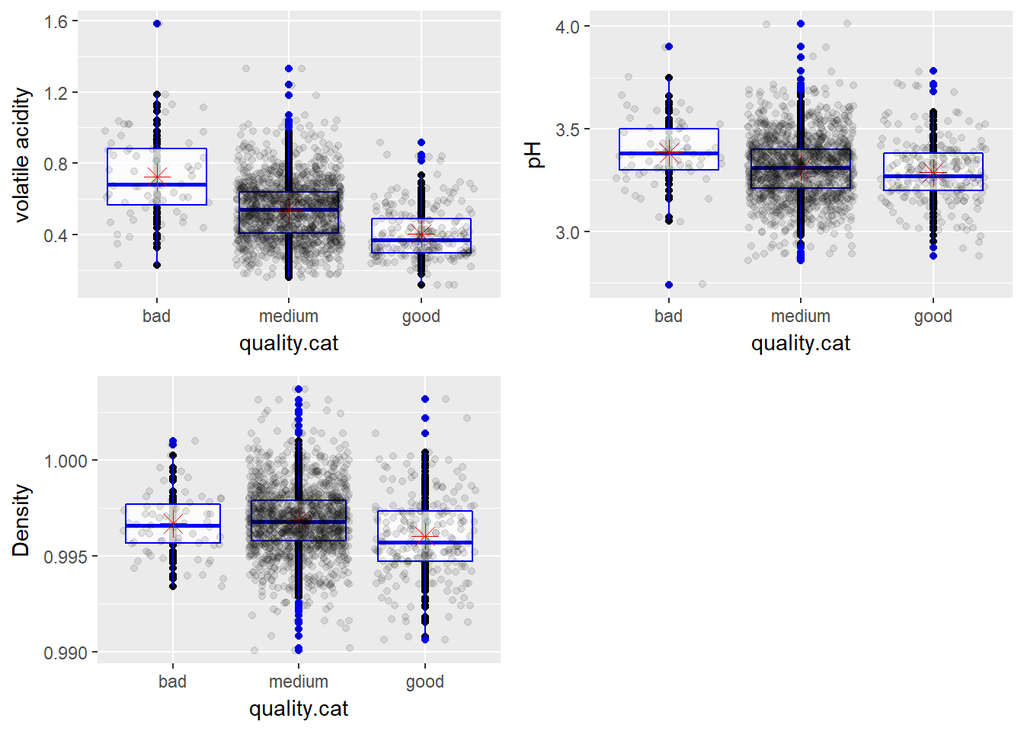

We already saw a tendency in the boxplots. But let’s use a scatter plot here, including a linear regression line.

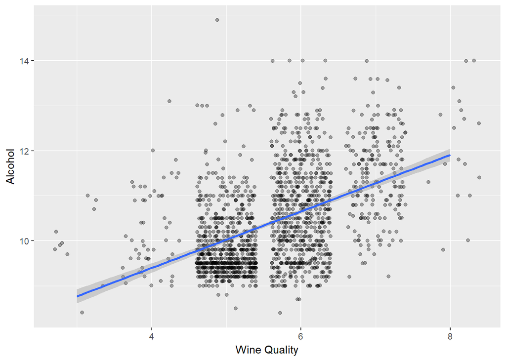

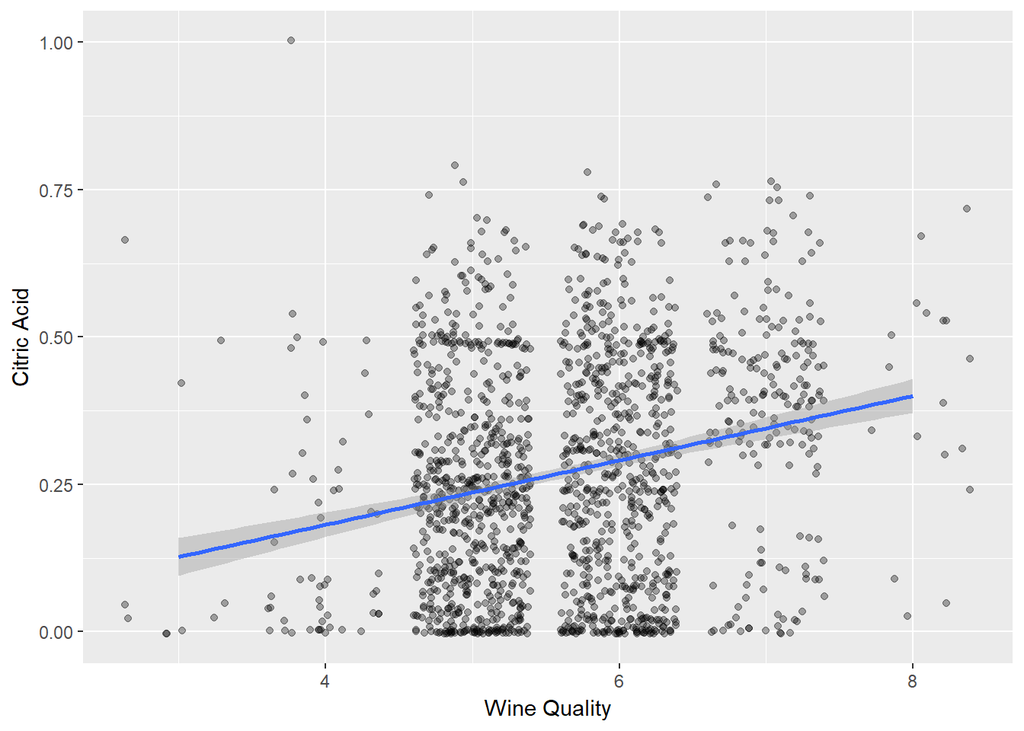

We can see a tendency. Good wines tend to have higher citric acid levels.

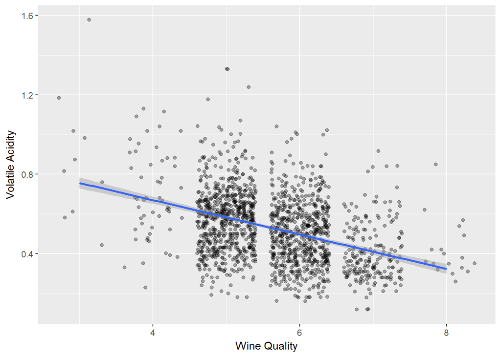

We can see the negative influence of volatile acidity in a wine’s quality score.

## Relating different variables

The ggpairs output uses groups histograms for qualitative/qualitative variables and scatterplots for quantitative/quantitative variables in the lower triangle of the plot. In the upper triangle, it provides boxplots for the qualitative/quantitative pairs of variables, and correlation coefficients for quantitative/quantitative pairs.

[figure not shown]

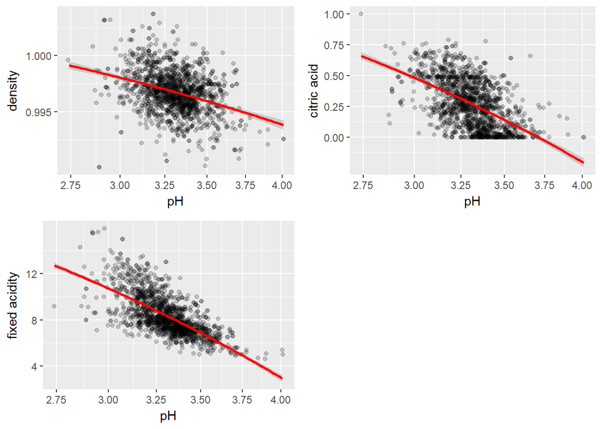

The highest positive correlation, according to a ggpairs matrix, is between density and fixed.acidity, as well as between fixed.acidity and citric.acid.

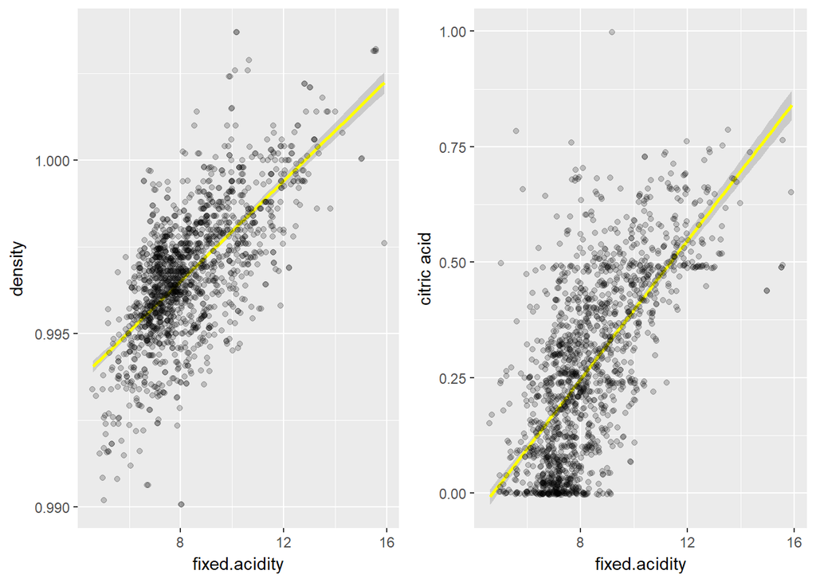

# Bivariate Analysis

### Talk about some of the relationships you observed in this part of the . How did the feature(s) of interest vary with other features in dataset?

Although the wine dataset features many different chemical attribute variables, most of them didn’t show much of a relationship with the variable of interest, wine quality. In the initial correlation matrix, it appears that volatile acidity, sulphates, and alcohol have the greatest association with wine quality.

In the more detailed examination of each chemical attribute variable and how it varies with wine quality, some interesting patterns did emerge.

### Did you observe any interesting relationships between the other features /(not the main feature(s) of interest)?

Some of the strongest associations were between chemical attribute variables, and not the main feature of interest (wine quality). There was a strong positive relationship between citric acid and fixed acidity, and negative relationships between citric acid and volatile acidity, and citric acid and pH, density and pH. There were also relationships between fixed acidity and pH and fixed acidity and density.

### What was the strongest relationship you found?

The strongest relationship between any chemical attribute variable and the variable of interest was between alcohol and quality (r-squared value of 0.476). The strongest relationship between any two variables was between pH and fixed acidity (r-squared value of -0.68).

# Multivariate Plots Section

In the previous boxplots we have seen that increasing levels of both sulphates and alcohol increase a perceived quality of red wine. Now, I create a scatterplot to see wheather a combination of these two may help distinguish between different quality levels.

[figure not shown]

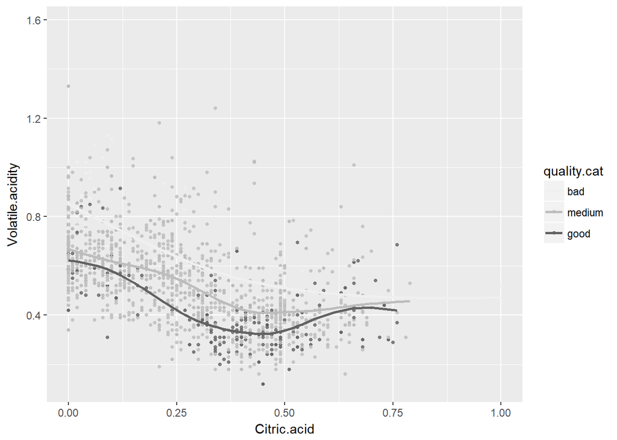

As we can see from the plot majority of good quality wines lies in lower part of plot.

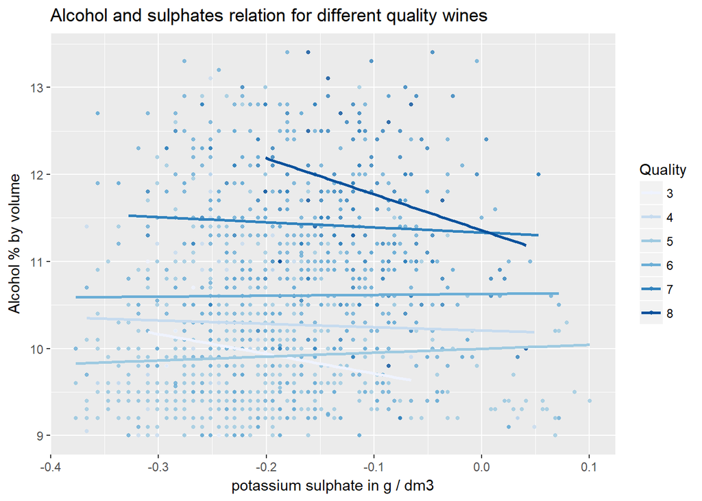

The plot reveals a clear pattern, showing most of darker dots (high-quality wine) in the place where both alcohol and sulphates level are high. There is also a visible range of 6 quality dots in the middle of the plot, and the zone of 4-5 quality dots in the bottom-left corner. This implies that such a combination of variables lets distinguish between different levels of medium-quality wines (5 and 6).

The previous plots show there is a positive corelation between the variables of density and fixed.acidity, so I create a dcatterplot to see wheather these two variables explain the quality changes well.

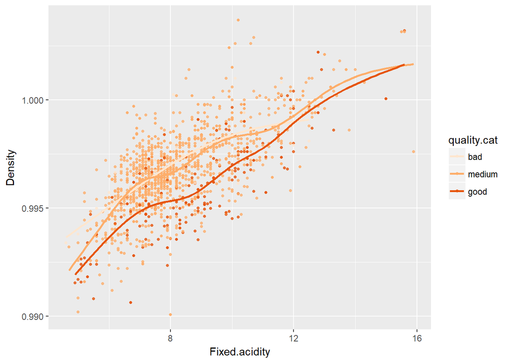

Although the plot is not very clear, it reveals some patterns in presented data. It is visible here that the majority of the medium & bad quality wines are in upper part of plot and good quality wines are in lower part. Thus, this combination of variables may be useful to distinguish medium quality wine from the good quality.

Other way of distinguishing between quality of wine is by using alcohol and volatile.acidity variables

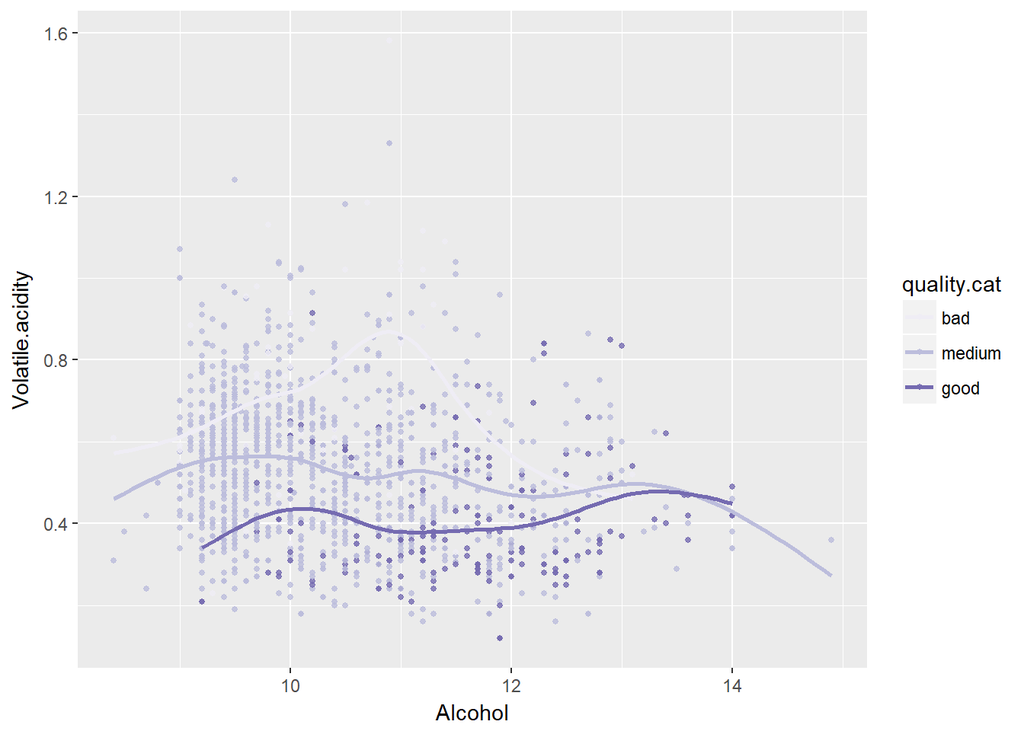

## Regression Model

I mostly use combinations of two and more variables for the multiple regression model predicting the quality of red wine. First combination consists of all the variables that increase the quality with their increasing levels. Next combination is density and fixed.acidity as its visual representation implied its value for predicting the quality. Next goes volatile.acidity, as this variable has the highest negative correlation coefficient with the quality variable. And the last combination consists of pH, total.sulfur.dioxide and free.sulfur.dioxide, based on the last step of the previous EDA.

```
##
## Calls:
## m1: lm(formula = quality ~ alcohol * sulphates * citric.acid * fixed.acidity,
##     data = pf)
## m2: lm(formula = quality ~ alcohol + sulphates + citric.acid + fixed.acidity +
##     density + alcohol:sulphates + alcohol:citric.acid + sulphates:citric.acid +
##     alcohol:fixed.acidity + sulphates:fixed.acidity + citric.acid:fixed.acidity +
##     fixed.acidity:density + alcohol:sulphates:citric.acid + alcohol:sulphates:fixed.acidity +
##     alcohol:citric.acid:fixed.acidity + sulphates:citric.acid:fixed.acidity +
##     alcohol:sulphates:citric.acid:fixed.acidity, data = pf)
## m3: lm(formula = quality ~ alcohol + sulphates + citric.acid + fixed.acidity +
##     density + volatile.acidity + alcohol:sulphates + alcohol:citric.acid +
##     sulphates:citric.acid + alcohol:fixed.acidity + sulphates:fixed.acidity +
##     citric.acid:fixed.acidity + fixed.acidity:density + alcohol:sulphates:citric.acid +
##     alcohol:sulphates:fixed.acidity + alcohol:citric.acid:fixed.acidity +
##     sulphates:citric.acid:fixed.acidity + alcohol:sulphates:citric.acid:fixed.acidity,
##     data = pf)
## m4: lm(formula = quality ~ alcohol + sulphates + citric.acid + fixed.acidity +
##     density + volatile.acidity + pH + total.sulfur.dioxide +
##     free.sulfur.dioxide + alcohol:sulphates + alcohol:citric.acid +
##     sulphates:citric.acid + alcohol:fixed.acidity + sulphates:fixed.acidity +
##     citric.acid:fixed.acidity + fixed.acidity:density + pH:total.sulfur.dioxide +
##     pH:free.sulfur.dioxide + total.sulfur.dioxide:free.sulfur.dioxide +
##     alcohol:sulphates:citric.acid + alcohol:sulphates:fixed.acidity +
##     alcohol:citric.acid:fixed.acidity + sulphates:citric.acid:fixed.acidity +
##     pH:total.sulfur.dioxide:free.sulfur.dioxide + alcohol:sulphates:citric.acid:fixed.acidity,
##     data = pf)
##
## ===========================================================================================
##                                                  m1        m2         m3          m4
## -------------------------------------------------------------------------------------------
##   (Intercept)                                   6.004   -16.407   -28.327     -47.730
##                                                (8.287)  (52.025)  (50.640)    (52.164)
##   alcohol                                      -0.248    -0.031    -0.006       0.166
##                                                (0.791)   (0.788)   (0.767)     (0.772)
##   sulphates                                    -1.259     1.733     1.544       1.326
##                                               (11.824)  (11.869)  (11.550)    (11.605)
##   citric.acid                                  24.816    31.954    33.083      36.242*
##                                               (18.651)  (18.861)  (18.354)    (18.386)
##   fixed.acidity                                 0.078    10.120     8.308       7.842
```

[output cut: 40 more lines]

```
##                                                                                (0.001)
##   pH:total.sulfur.dioxide:free.sulfur.dioxide                                  -0.001***
##                                                                                (0.000)
## -------------------------------------------------------------------------------------------
##   R-squared                                        0.3       0.3        0.4         0.4
##   adj. R-squared                                   0.3       0.3        0.4         0.4
##   sigma                                            0.7       0.7        0.6         0.6
##   F                                               52.7      48.4       53.2        40.4
##   p                                                0.0       0.0        0.0         0.0
##   Log-likelihood                               -1602.7   -1591.9    -1547.7     -1530.3
##   Deviance                                       695.0     685.6      648.8       634.8
##   AIC                                           3239.5    3221.7     3135.4      3114.6
##   BIC                                           3330.9    3323.9     3243.0      3259.8
##   N                                             1599      1599       1599        1599
## ===========================================================================================
```

The given model explains 40% of cases in the given dataset. The highest R-squared = 0.333 is provided by the first combination of parameters (alcohol, sulphates, citric.acid, fixed.acidity). Next three sets of features add 0.01-0.03 to the previous R-squared value.

This model has limitations. It is based on the limited data that does not provide very high (more than 8) and very low (less than 3) quality scores. Collecting the data with more cases of extreme scores, as well as additional data with existing low-quality scores (3 and 4), could significantly improve the model’s predictive power.

# Multivariate Analysis

### Were there any interesting or surprising interactions between features?

I thought that the most interesting interaction was between alcohol and volatile acidity. Although both alcohol and volatile acidity are associated with wine quality, they don’t have a very strong relationship with each other. However, when you plot them together you can see how wines of different qualities separate into different sides of the plot.

### OPTIONAL: Did you create any models with your dataset? Discuss the and limitations of your model.

I created a linear model that used all the variables except residual.sugar and chlorides as the predictor variables and wine quality as the outcome variable. The overall r-squared value for the model wasn’t very high (0.4) but I think that it is still a useful model because it shows the relative importance of each of the predictor variables, as the r-squared value increases slightly with each addition. The most important predictor in the model is alcohol. I think that one of the strengths of the model is that it is clear and easy to interpret. The model is limited by the lack of variation in the dataset among the outcome variable, wine quality.

# Final Plots and Summary

### Plot One

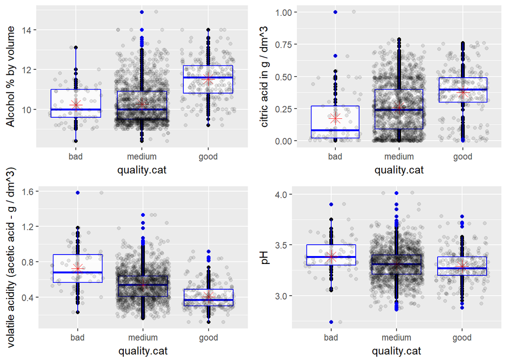

### Plot Two

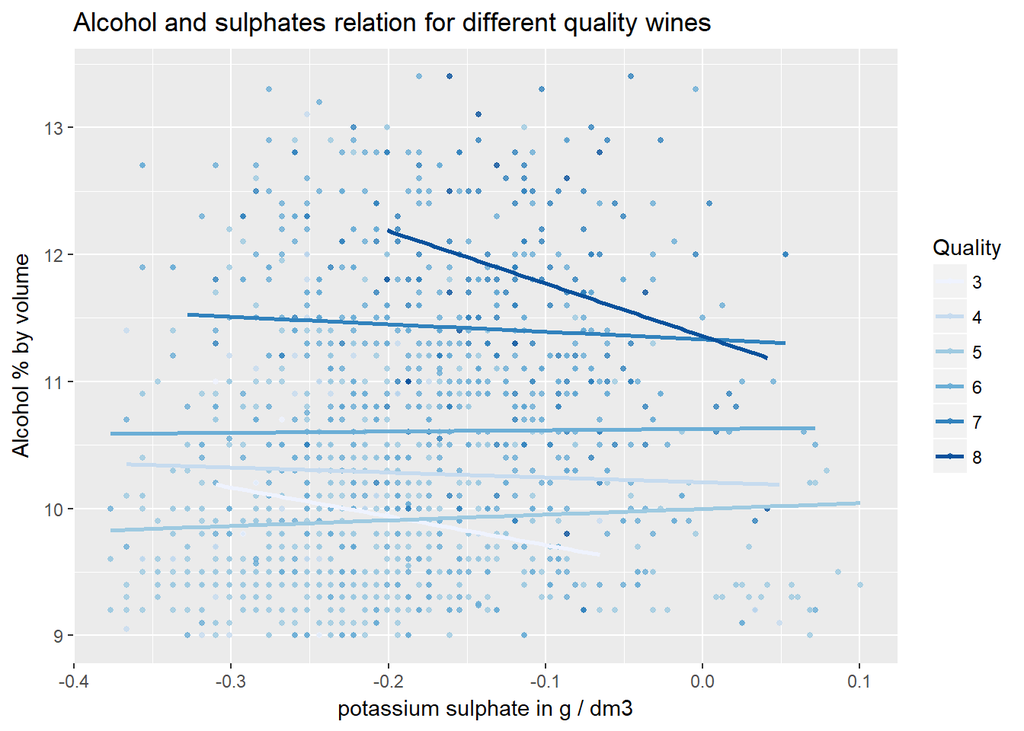

### Description Two

The plot reveals a clear pattern, showing most of darker dots (high-quality wine) in the place where both alcohol and sulphates level are high. There is also a visible range of 6 quality dots in the middle of the plot, and the zone of 4-5 quality dots in the bottom-left corner. This implies that such a combination of variables lets distinguish between different levels of medium-quality wines (5 and 6).

### Plot Three

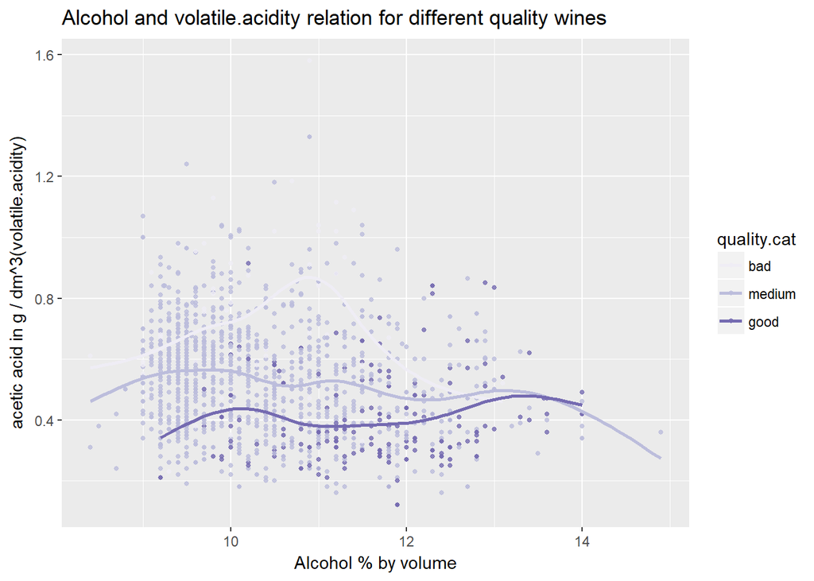

### Description Three

Wines with good quality has lesser volatile.acidity in them. white dots are in the upper part of plot which means bad quality wines has more volatile.acidity in them.

### summary

citric acid and fixed acidity strengthened each other when looking at wine quality, because both appear to be positively associated with wine quality. The strongest relationship between any chemical attribute variable and the variable of interest was between alcohol and quality (r-squared value of 0.476). The strongest relationship between any two variables was between pH and fixed acidity (r-squared value of -0.68).Multiple regression model is able to explain up to 40% of existing cases in the dataset. Additional dataset with more data of extreme quality cases (both high and low-quality) should help improve the results of this model.

# Reflection

This dataset contained 1,599 observations of red wines. Each wine received a quality rating and had information on 11 different chemical attributes. My main interest in exploring this dataset was to try to learn about how the chemical attributes of a wine might be associated with its quality rating. Through a combination of graphical and statistical analysis, I was able to assess the different relationships between the predictor and outcome variables.

One of the major challenges in this analysis was the limitations of the dataset. The variable of interest, wine quality, was an integer value measured on a scale of 0 to 10. However, the vast majority of the wines (1,319 out of 1,599) received a score of 5 or 6. Only 63 wines received a score of 3 or 4, and 217 wines received a score of 7 or 8. No wines received scores of 0, 1, 2, 9, or 10. Since the wine quality variable had such limited variability, it was difficult to assess the relationship between quality and the chemical attribute variables. Additional dataset with more data of extreme quality cases (both high and low-quality) should help improve the results of this model. Moreover, more sophisticated prediction models should be able to provide more accurate predictions for the quality of wine based on its chemical characteristics.

Aside from the issues with the wine quality variable, I really enjoyed working with this dataset. Having such complete data on so many different chemical attributes provided many opportunities to assess the interactions between different predictor variables as well as the variable of interest. It would be very interesting to combine this dataset with the white wine dataset to see if there are any associations that are similar or different between the two types of wine. It would be fascinating to see how the chemical attributes compare between red and white wines and if the same predictor variables are associated with wine quality.